# Task 1: Data wrangling & visualization (Sierra amphibians)

By: Claire Gonzales

1/24/2022

### Project Overview

This report explores the abundance data of mountain yellow-legged frog (Rana muscosa), as observed from the Sierra Lakes Inventory Project between the years 1995-2002 in the Sierra Nevada region of California.

(Knapp et al 2020)

```r
knitr::opts_chunk$set(echo = TRUE, message=FALSE, warning=FALSE)

# attaching packages

library(tidyverse)
library(here)
library(cowplot)
library(patchwork)
library(lubridate)
library(paletteer)
```

```r
# reading in csv data

sierra_amph <- read_csv(here("data", "sierra_amphibians.csv"))
```

### Data Wrangling

#### Dataset 1

Creating a subset of data to demonstrate the total mountain yellow-legged frog (Rana muscosa) count each year across all water bodies, by life stage excluding the ‘EggMass’ level.

```r
ramu_sub <- sierra_amph %>%
  filter(amphibian_species == "RAMU") %>%
  filter(amphibian_life_stage %in% c("Tadpole", "Adult", "SubAdult")) %>%
  mutate(survey_date = mdy(survey_date)) %>% #transform date from myd format to YYYY-MM-DD format
  mutate(year = year(survey_date)) %>%
  group_by(year, amphibian_life_stage) %>% # group by year
  summarize(count = sum(amphibian_number))
```

#### Dataset 2

Create a second dataset of total counts (over all years of the study) of combined adult and subadult endangered mountain yellow-legged frogs (Rana muscosa) observed in the 5 lakes with the greatest total observed counts.

```r
ramu_top_lakes <- sierra_amph %>%
  filter(amphibian_species == "RAMU") %>%
  filter(amphibian_life_stage %in% c("Adult", "SubAdult")) %>%
  mutate(survey_date = mdy(survey_date)) %>% #transform date from myd format to YYYY-MM-DD format
  mutate(year = year(survey_date)) %>%
  group_by(lake_id) %>%
  summarize(count = sum(amphibian_number)) %>%
  arrange(-count) %>%
  mutate(lake_id = factor(lake_id, levels = lake_id)) %>%
  slice_max(count, n = 5)
```

### Data Visualization

#### Visualization 1

```r
plot1 <- ggplot(data = ramu_sub, aes(x = year, y = count)) +
  geom_col(stat = "identity", aes(fill = amphibian_life_stage)) +
  labs(x = "Year",
       y = "Count",
       fill = "Life stage") +
  theme_minimal() +
  scale_fill_paletteer_d(palette = "basetheme::minimal") +
  theme(legend.position='bottom', axis.text.x = element_text(angle = 45))
```

#### Visualization 2

```r
plot2 <- ggplot(data = ramu_top_lakes, aes(x = lake_id, y = count, fill = lake_id)) +
  geom_col() +
  labs(x = "Lake ID",
       y = "Count",
       fill = "Lake ID") +
  theme_minimal() +
  scale_fill_paletteer_d(palette = "calecopal::sbchannel") +
  theme(legend.position= 'none', axis.text.x = element_text(angle = 45))
```

### Combined Visualization

Creating one figure with both visualizations.

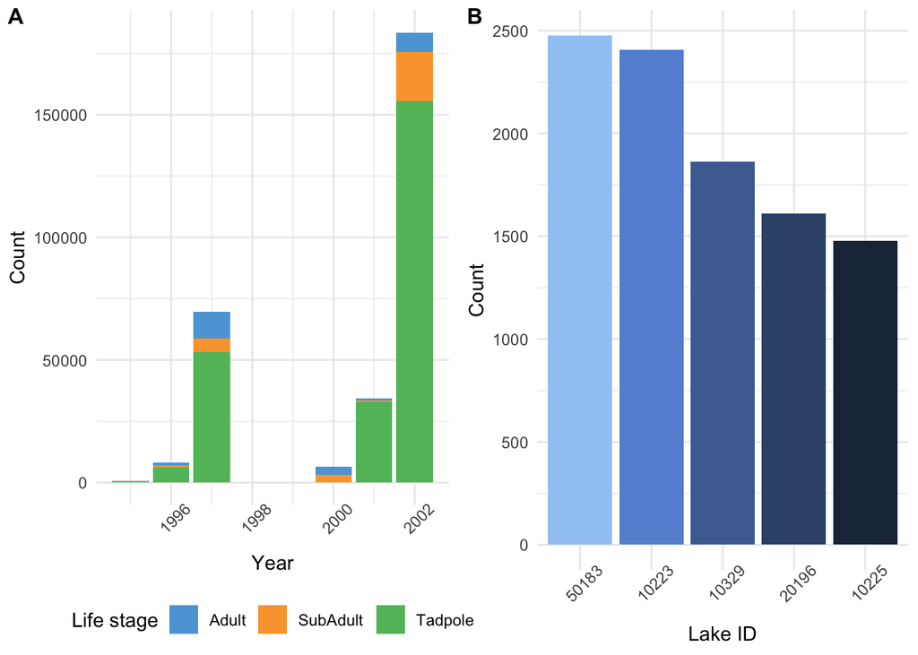

```r
plot_grid(plot1, plot2, labels = c('A', 'B'), label_size = 12)
```

**Figure 1** Shows the observed abundances of mountain yellow-legged frog (R. muscosa) as recorded by the The Sierra Lakes Inventory Project 1995-2002 (Knapp et al. 2020). *Pane A* reflects the total count of mountain yellow-legged frogs each year across all water bodies, by life stage excluding the ‘EggMass’ level. *Pane B* reflects total counts (over all years of the study) of combined adult and subadult endangered mountain yellow-legged frogs observed in the 5 lakes with the greatest total observed counts.

### Citations

Knapp, R.A., C. Pavelka, E.E. Hegeman, and T.C. Smith. 2020. The Sierra Lakes Inventory Project: Non-Native fish and community composition of lakes and ponds in the Sierra Nevada, California ver 2. Environmental Data Initiative. https://doi.org/10.6073/pasta/d835832d7fd00d9e4466e44eea87fab3